# ADSProj1

Wenwen Shen

9/15/2019

# Part1: Load data

### I loaded data of artist and processed lyrics. And I also creadted a emotional vector, which contains “love”, “happy”, “joy”, “smile”, “sweet”,“sad”, “anger”, “fear”,“cry”,“hate”,“fear”. To check if the emotional is different from each period and each genre.

```
## # A tibble: 10 x 7
##    song      year artist genre lyrics              id stemmedwords
##    <chr>    <dbl> <chr>  <chr> <chr>            <int> <chr>
##  1 when-yo…  2009 a      Hip-… "I stopped by t…     1 stop house call home…
##  2 careles…  2009 a      Hip-… "I feel so unsu…     2 unsure hand lead dan…
##  3 2-59      2007 a      Hip-… "Mark:] Sunday …     3 mark sunday football…
##  4 power-o…  2007 a      Hip-… "[Chris:] Falli…     4 chris fallin fantasy…
##  5 you-re-…  2007 a      Hip-… "something in t…     5 touch hold hand hold…
##  6 nothing   2007 a      Hip-… "Nothing\nAnd n…     6 nothings youre youll…
##  7 bad-bit…  2013 a      Hip-… "(Hahahaha)\nYe…     7 hahahaha ghetto supe…
##  8 stranger  2013 a      Hip-… "If it's one th…     8 ive learn ive writte…
##  9 better-…  2005 a      Hip-… "Run around,\nW…     9 run whats frequency …
## 10 die-ton…  2005 a      Hip-… "Lose yourself,…    10 lose save night time…
```

# Part2: Frequency of emotional words by years.

### I checked the frequency words for each time periods, but the frequency of each emotional word are not very different during 1970s to 2010s.

```
##     Word  Freq1970s  Freq1980s   Freq1990s  Freq2000s   Freq2010s
## 1  anger 0.01143791 0.01016949 0.007320979 0.01293626 0.008185592
## 2    cry 0.21732026 0.24067797 0.235872798 0.20029201 0.196260232
## 3   fear 0.05065359 0.05677966 0.072752231 0.09378523 0.094308880
## 4  happy 0.13071895 0.10847458 0.086707847 0.08995266 0.086200877
## 5   hate 0.03513072 0.06949153 0.069778083 0.09805795 0.109050704
## 6    joy 0.03104575 0.02457627 0.031800503 0.03421400 0.034138961
## 7   love 1.89297386 2.16610169 1.656829101 1.43723497 1.864026070
## 8    sad 0.08251634 0.07203390 0.069320522 0.06184715 0.056174109
## 9  smile 0.12826797 0.10169492 0.122168840 0.11075803 0.113279280
## 10 sweet 0.27124183 0.15000000 0.156714711 0.11536356 0.118671684
```

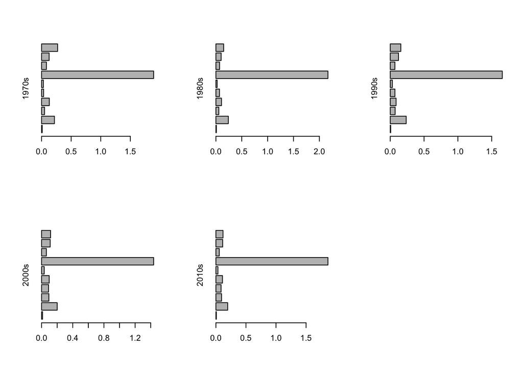

# Part3: Frequency of emotional words by genre.

### I am trying to find which kind of emotion is stronger, seperated by different genre.

## 3.1 Filtered lyrics by genre.

### I filtered the words by emotional words from genre and emo.vector. Then, I calculated the frequency of each word by dividing the number of the songs from that genre. After that, I used frequency of each word from each genre to form a data frame.

```
##    Words       Folk     Country  Electronic      Metal         R&B
## 1  anger 0.01280180 0.005972923 0.007112376 0.04217134 0.006899724
## 2    cry 0.12801797 0.231882134 0.162517781 0.19609230 0.316007360
## 3   fear 0.07961819 0.035306610 0.083926031 0.24984528 0.058417663
## 4  happy 0.08119034 0.123971330 0.070412518 0.02837945 0.142594296
## 5   hate 0.26400898 0.043005044 0.060099573 0.20608257 0.040938362
## 6    joy 0.04110051 0.030395540 0.031650071 0.02484307 0.064397424
## 7   love 1.71072431 1.766392355 1.730085349 0.43055433 2.785188592
## 8    sad 0.04514318 0.069949562 0.047297297 0.04836000 0.070377185
## 9  smile 0.11521617 0.125829573 0.107396871 0.07152330 0.140754370
## 10 sweet 0.08893880 0.194451818 0.113798009 0.05516754 0.209291628
##       Hip-Hop
## 1  0.01280180
## 2  0.12801797
## 3  0.07961819
## 4  0.08119034
## 5  0.26400898
## 6  0.04110051
## 7  1.71072431
## 8  0.04514318
## 9  0.11521617
## 10 0.08893880
```

## 3.2: Comparison of Metal and Country

### From the table above, I decided to choose Metal and Country to compare. For the picture below, the left ones are Metal, and the right ones are Country.

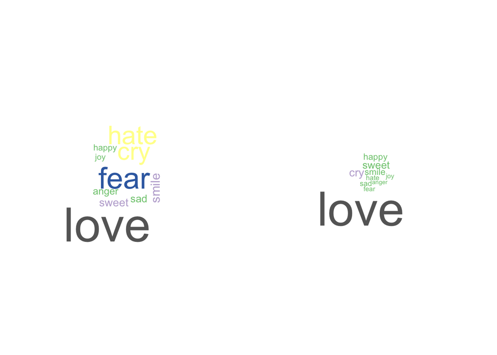

##### From the size of each emotional words above, we could easily find Metal is more emotional, since the “fear” and “hate” shows a lot. However, Country is more gentle. There are more clear comparison below.

#### Frequency of emotional words from Metal and Country.

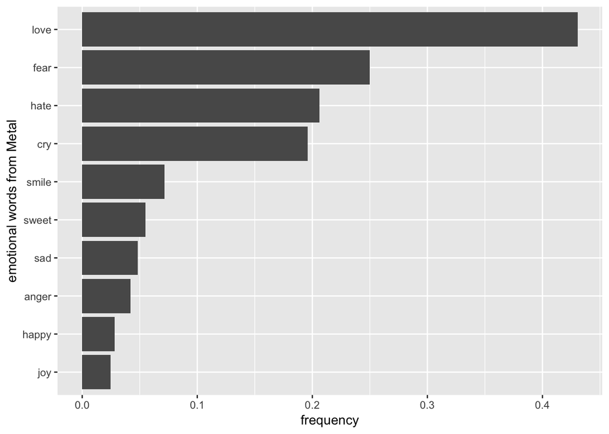

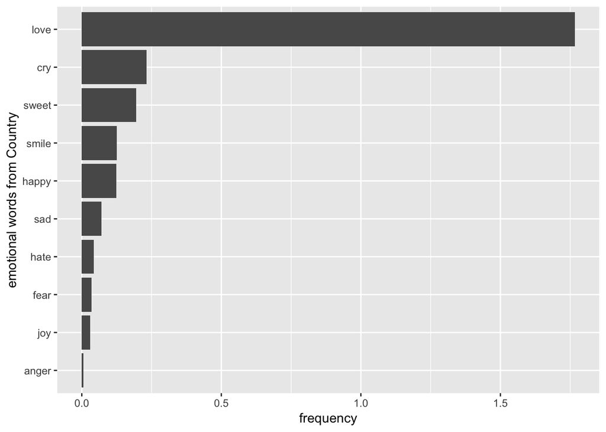

## 3.3 Wordcloud of all words from Metal and Country

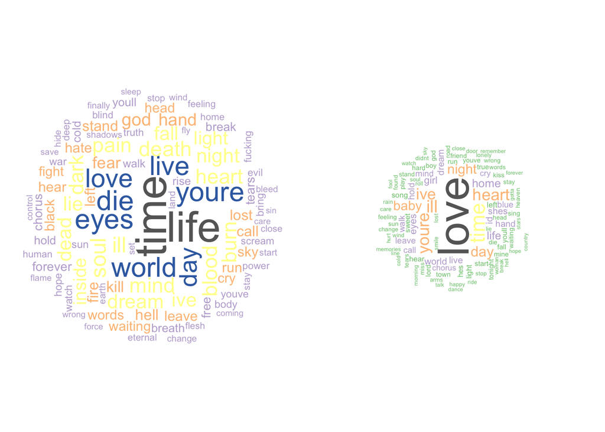

##### By finding “kill”, “hate”, “dead”, “cry” ect strong words from Metal, and “baby”, “life”, “home” ect temperance words from Country, we can also show the conclusion above. Therefore, Metal is a stronger emotional genre, compared with Country.